# Zarządzanie kodem w R

## Skrypty w R

## Kształt typowego skryptu

1. Wczytanie bibliotek.
- jest to potrzebne do używania znajdujących się w nich funkcji
- wypisanie bibliotek na początku pomaga nowej osobie w sprawnej ich instalacji
1. Wczytanie dodatkowych skryptów.
- w dodatkowych skryptach mogą być funkcje, z których chcemy później korzystać
1. Kod.

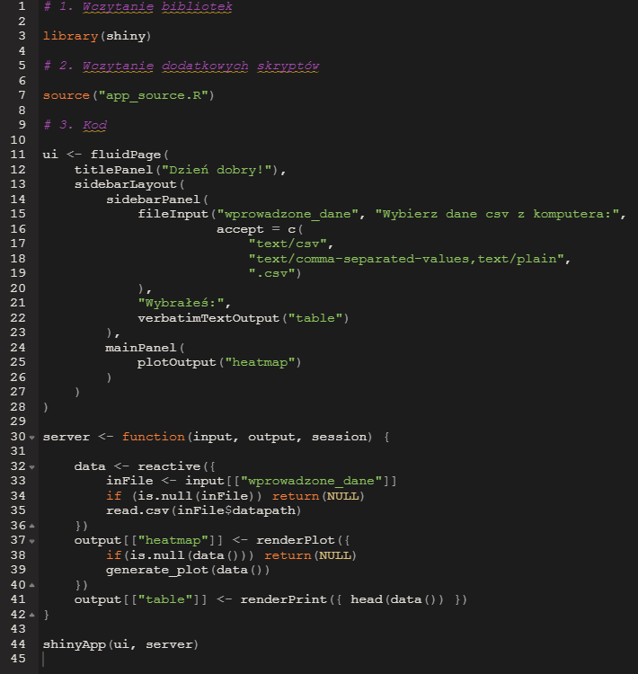

## Problemy z dzieleniem się skryptami

1. Zmienne środowiskowe:
- **working directory** - bezwzględna ścieżka na komputerze prowadząca do domyślnej lokalizacji plików wczytywanych do R lub zapisywanych z R

```r
# sciezka bezwzgledna na danym urzadzeniu - zadziała tylko u Michala
read.csv("C:/Michal/projekt/dane.csv")

# getwd() zwraca working directory
getwd()

# setwd() zmienia working directory
setwd("C:/Krysia/projekt")
read.csv("dane.csv") # zadziała u Krysi
```

Zmiana working directory z poziomu Rstudio

[figure not shown]

**options** - funkcja *options()* pozwala użytkownikowi na zmianę różnych opcji opisujących sposób, w jaki R liczy oraz wyświetla wyniki. Wywołanie **options()** - zwraca wszystkie obecnie ustawione opcje.

## Przykład 1 - cyfry znaczące

- **digits** - ustawia ilość wyświetlanych cyfr znaczących (domyślnie 7)

```r
options(digits = 10)
print(pi)
```

```
## [1] 3.141592654
```

```r
options(digits = 3)
print(pi)
```

```
## [1] 3.14
```

## Przykład 2 - warningi i errory

- warning - informacja dla użytkownika (np. o możliwym błędzie), nie przerywa działania funkcji
- error - błąd, w wyniku którego działanie funkcji zostaje przerwane
- **warn** - liczbą całkowitą określamy sposób obchodzenia się z warningami (warn < 0 - wszystkie warningi są ignorowane, warn = 0 - warningi są wyświetlane kiedy funkcja zwróci ostateczny wynik, warn = 1 - warningi są wyświetlane na bieżąco, warn > 1 - warningi są traktowane jak errory)

```r
options(warn = 1)
warning("Hello, it is a warning!")
```

```
## Warning: Hello, it is a warning!
```

```r
options(warn = -1)
warning("Hello, it is an ignored warning!")
```

- **inne cechy**, np. liczba rdzeni (i inne parametry, które mogą sprawić, że kod, który działał u nas nie zadziała).

```r
library(parallel)
detectCores()
```

```
## [1] 8
```

```r
l <- list(A = rnorm(10), B = rnorm(100))

mclapply(l, function(vec) {
  mean(vec)
}, mc.cores = 4)
```

```
## $A
## [1] -0.0891
##
## $B
## [1] 0.0641
```

1. Konflikty nazw.

Zdarza się, że nazwy obiektów pokrywają się pomiędzy różnymi pakietami.

Przykład: funkcja *filter()* z pakietów *dplyr* i *stats*.

```r
library(stats)
library(dplyr)
```

Wywołując teraz funkcję *filter()* użyjemy funkcji z pakietu dplyr - do filtrowania ramek danych

```r
filter(iris, Sepal.Length == 5.1, Sepal.Width == 3.5)
```

```
##   Sepal.Length Sepal.Width Petal.Length Petal.Width Species
## 1          5.1         3.5          1.4         0.2  setosa
## 2          5.1         3.5          1.4         0.3  setosa
```

Możemy sprecyzować pakiet, z którego chcemy importować konkretną funkcję. W przypadku pakietu *stats* i funkcji *filter()* zrobimy to następująco:

```r
x <- 1:15
stats::filter(x, rep(1, 3))
```

```
## Time Series:
## Start = 1
## End = 15
## Frequency = 1
##  [1] NA  6  9 12 15 18 21 24 27 30 33 36 39 42 NA
```

1. Wersje bibliotek.

Biblioteki w R są ciągle ulepszane, więc warto precyzować wersję biblioteki, w której kod działa poprawnie. Na przykład:

```r
example_list <- list(iris, iris)
dplyr::rbind_list(iris, iris) #nie działa
```

```
## [1] "Error: 'rbind_list' is not an exported object from 'namespace:dplyr'"
```

W najnowszych wersjach pakietu *dplyr* funkcję *rbind_list()* zastąpiła funkcja *bind_rows()*.

```r
dplyr::bind_rows(example_list) #działa
```

```
##   Sepal.Length Sepal.Width Petal.Length Petal.Width Species
## 1          5.1         3.5          1.4         0.2  setosa
## 2          4.9         3.0          1.4         0.2  setosa
## 3          4.7         3.2          1.3         0.2  setosa
```

Historię zmian w pakiecie *dplyr* można sprawdzić tutaj

https://dplyr.tidyverse.org/news/index.html

Jak sprawić, żeby stary kod używający funkcji *rbind_list()* nadal działał?

- Ładujemy starszą wersję pakietu - dplyr 0.8.5

```r
detach("package:dplyr", unload = TRUE)

url <- "https://cran.r-project.org/src/contrib/Archive/dplyr/dplyr_0.8.5.tar.gz"
install.packages(url, repos=NULL, type="source")
```

- Starsze wersje pakietów można znaleźć w archiwum Cranu:

https://cran.r-project.org/src/contrib/Archive/dplyr/

## Projekty w RStudio

## Zalety projektów

- zachowuje working directory,
- zachowuje historię,
- zachowuje ustawienia RStudio,
- zachowuje environment (choć to może też być problem),
- personalizowany Rprofile
- wraz z renv zachowuje wersje pakietów,
- wraz z gitem pozwala kontrolować historię wersji.

## Tworzenie projektu

[figure not shown]

## New directory

[figure not shown]

[figure not shown]

## Existing directory

[figure not shown]

## Globalne środowisko

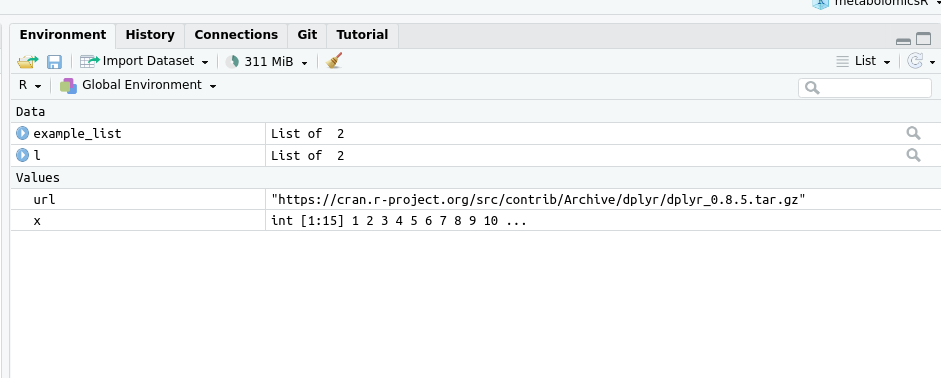

## Historia

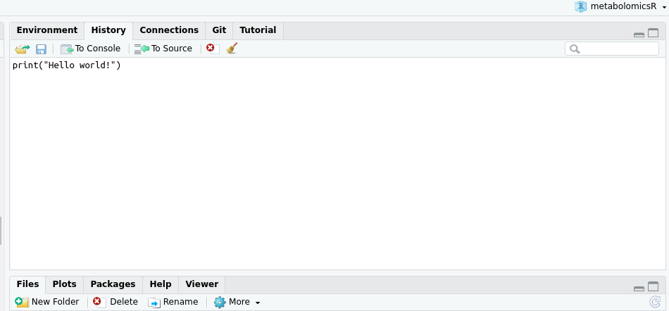